# Lec 18

## Review

> All **random variables** have a **random probability distribution**

> As all **statistics** are random variables:

> **All statistics arise from a random probability distribution**

The probability distribution of a sample statistic is the **sampling distribution**

Let $\bar{x}$ be the mean of a random sample of size $n$, drawn from a population with mean $\mu$ and standard deviation $\sigma$

Since $\bar{x}$ is a random variable, it has the mean and the standard deviation

The mean of $\bar{x}$ is $\mu$

$$\mu_{\bar{x}} = \mu = \text{population mean}$$

The standard deviation of $\bar{x}$ is $\sigma / \sqrt{n}$

$$\sigma_{\bar{x}} = \frac{\sigma}{\sqrt{n}}$$

**Questions?**

## Distribution Theory

### Discrete Probability Distributions

> Flip a coin twice

> How many outcomes are possible?

$$\begin{array}{|c|c|}
\hline
\text{Flip 1} & \text{H} & \text{H} & \text{T} & \text{T}\\
\hline
\text{Flip 2} & \text{H} & \text{T} & \text{H} & \text{T}\\
\hline
\end{array}$$

**We can reframe this table so that it’s possible to do math with it:**

$$\text{Let } \ \text{H}=1 \text{ and } \text{T} =0$$

$$\begin{array}{|c|c|}
\hline
\text{Flip 1} & 1 & 1 & 0 & 0\\
\hline
\text{Flip 2} & 1 & 0 & 1 & 0\\
\hline
\end{array}$$

Does Flip 1 have any affect on Flip 2?

Any individual, independent, binary event is referred to as a *Bernoulli Trial*

Take our coin flip table and make a slight adjustment:

$$\text{Let } \ P\equiv\{\text{Patient is sick} \}=1 \text{ and } N\equiv\{\text{Patient is healthy}\} =0$$

$$\begin{array}{|c|c|}
\hline
\text{Patient 1} & 1 & 1 & 0 & 0\\
\hline
\text{Patient 2} & 1 & 0 & 1 & 0\\
\hline
\end{array}$$

> Bernoulli trials are modeled by the Bernoulli distribution, a discrete distribution for individual, independent binary outcomes

$$P(X=1)=p$$
$$P(X=0)=1-p$$

$$X\sim \text{Bern}(p)$$

$$[X]=\begin{cases} p & \text{for } X=1 \\ 1-p & \text{for } X=0\end{cases}$$

Given a fair coin, the probability of getting a heads, $(1)$, is $p=0.5$

The probability of getting a tails, $(0)$, is $1-p=0.5$

This concept continues to apply regardless of the shift in probability:

$$\text{Probability of getting rabies from a bat} \approx 10^{-6}$$

$$[X]=\begin{cases} 10^{-6} & \text{for } X=1 \\ 0.999999 & \text{for } X=0\end{cases}$$

When we stack Bernoulli trials together $n$ many times and sum them, we model this with the **Binomial Distribution**

$$P(X=x)={n\choose k}p^k(1-p)^{n-k}$$

$$n\choose k$$

“n choose k” is referred to as the **binomial coefficient** and is formally defined as:

$$n! \over k!(n-k)!$$

$$\text{Where } n! = 1\times2\times3\times...\times n$$

> The number of ways to choose k things from a group of size n

> Flip a coin ten times, how many possible configurations can result in 4 heads being flipped?

$${10 \choose 4}={10! \over 4!(10-4)!}=210$$

> What’s the probability of flipping exactly 4 heads from 10 tosses?

$$P(X=4)={10\choose 4}0.5^4(1-0.5)^{10-4}$$

$$=210*0.0625*0.015625=0.2050781$$

Why would we care?

Assumptions are the core of science and statistics

If we assume that our outcomes of our study are **binary** (i.e., $0 \text{ or }1$)

It’s **convenient** to work with the assumption directly:

$$\text{Let } X \equiv \{\text{A captured raccoon is already tagged}\}$$

$$P(X=x)=
\begin{cases}
0.2 & \text{if } \ x=1 \\
0.8 & \text{if } \ x=0 \\
\end{cases}$$

We have the tools to tell us what the probability of two individually captured raccoons being tagged is:

$$0.2*0.2=0.04$$

We have the tools to answer the probability of $n$ many individually captured raccoons **not** being tagged is:

$$(1-0.2)^n=0.8^n$$

This tool now allows us to work with actual data

> Given that there are $1000$ raccoons captured, what is the probability that we capture 200 that have already been tagged?

$$P(X=200)={1000\choose 200}0.2^{200}(1-0.2)^{1000-200}=0.03152536$$

We can easily see that this is $\neq 0.2^{200}$

We aren’t asking **subsequent capture probabilities**

We’re asking within our sample of $1000$, how likely are we to see **exactly** ${1/5}^{th}$ of the raccoons to be previously tagged

Just like with the Normal Distribution, we have an **Expectation** and **Variance** associated with the binomial:

$$X \sim \text{Binom}(n,p)$$

$$\mathbb EX=np$$

$$\mathbb VX=np(1-p)$$

> How many raccoons should we expect to be previously tagged in our sample of 1000?

$$1000*0.2=200$$

> By how much should subsequent samples vary?

$$1000*0.2(1-0.2)=160$$

$$\sqrt{160}=12.65$$

```r
set.seed(78)
samples=replicate(10,sum(rbinom(1000,1,0.2)))
mean(samples)
```

```
[1] 200.4
```

```r
var(samples)
```

```
[1] 126.9333
```

```r
sqrt(var(samples))
```

```
[1] 11.26647
```

What happens with our LLN and CLT with the binomial?

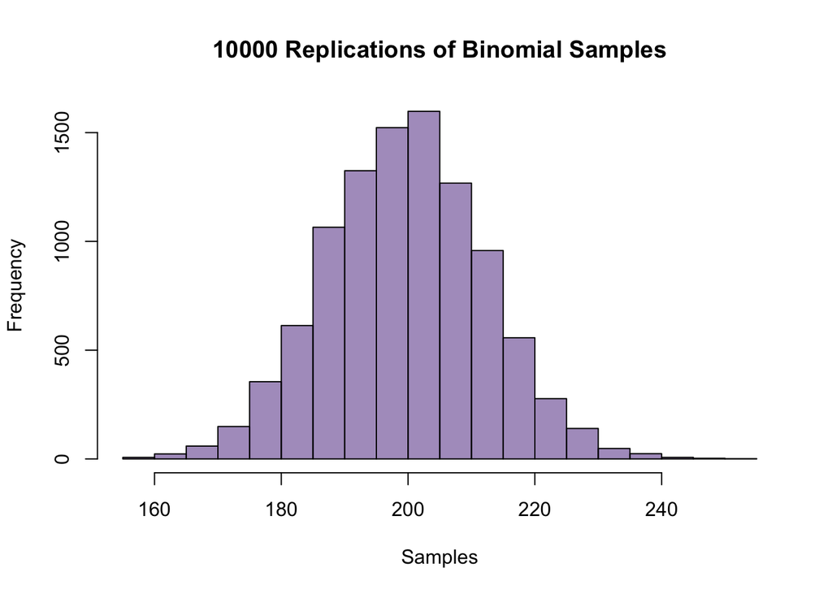

If we standardize all of our binomial samples:

$$Z={x-\mu \over \sigma}={X_i-200 \over 12.65}$$

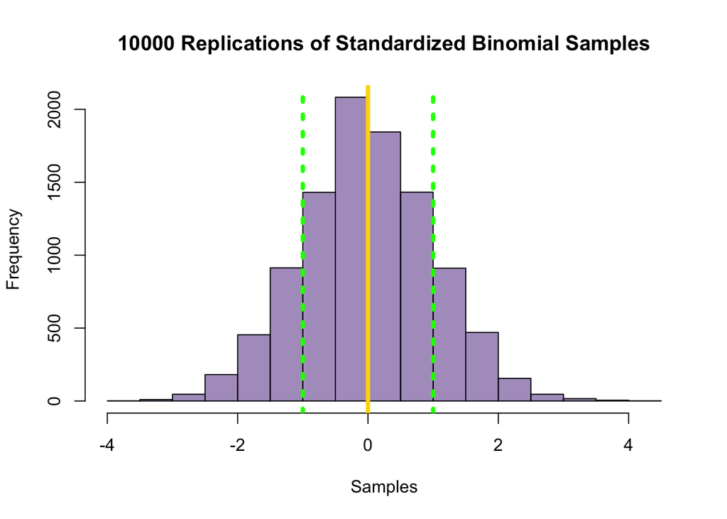

> Imagine you’re counting the number of deer found within any given acre of a wildlife preserve. You could assume a binary outcome (0 if the deer isn’t seen, 1 if it is), but this doesn’t work well if you don’t know the total number that *can* be in that acre.

As we stack Bernoulli trials infinitely and set the probability in our Binomial distribution closer and closer to zero, we converge on the **Poisson Distribution**

$$P(X=x)={\lambda^xe^{-\lambda}\over x!}$$

The Poisson distribution models the probability associated with **strictly positive count data**:

- The number of deer in an acre of land
- The number of fish in a pond
- The number of individuals that are on a cruise ship

A unique feature of the Poisson distribution is that it’s **expectation** and **variance** are the same parameter: $\lambda$

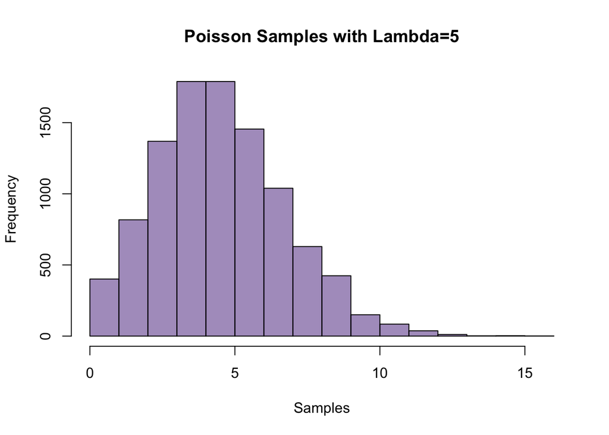

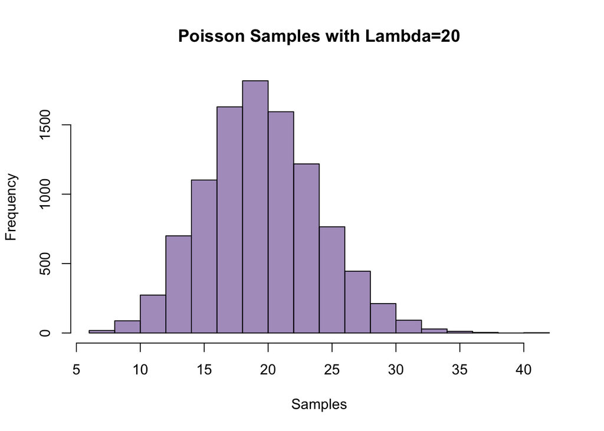

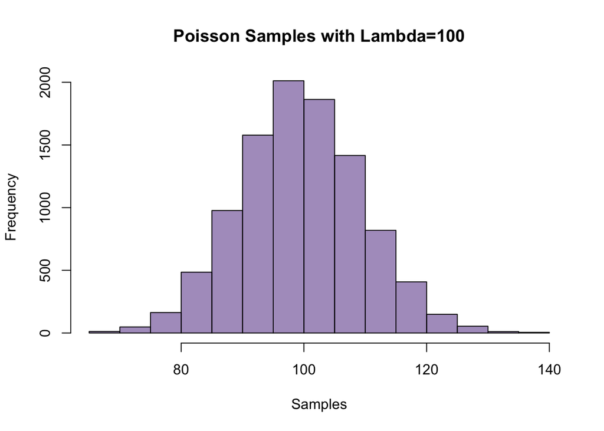

### Continuous Probability Distributions

**What if we want to model the probability of our binary outcome?**

> What is the prevelance of blight in any randomly selected potato patch in the country?

Let $X \equiv \{\text{Blight prevelance for a selected patch}\}$

$$S_x=\{0,1\}$$

Our data is the prevalence, which is a **proportion**:

- Strictly positive
- Bounded between $0$ and $1$

We can’t model this with the normal distribution

We *could* set the variance of our normal distribution such that only values between $0$ and $\pm 1$ spit out, then take the absolute values

That’s going to be messy to get right

We can make transformations to our probability data and work with it *as if* it was normal

- Microbiologists and plant pathologists are guilty of this
- It works, but not consistently and it causes problems down the road

For **proportions and probabilities**, we use the **Beta Distribution**:

$$X \sim \text{Beta}(\alpha,\beta)$$

The pdf of the Beta distribution is a fairly involved equation, so distribution notation is more useful here

$\alpha$ and $\beta$ **both** control the shape of the distribution:

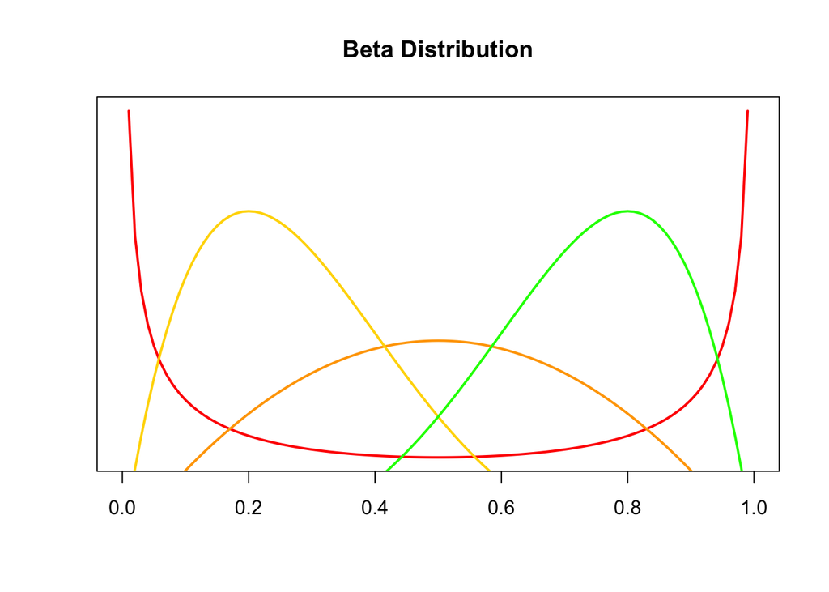

The **expectation** of the Beta distribution:

$$\alpha\over \alpha+\beta$$

The **variance**:

$$\alpha\beta\over (\alpha + \beta)^2(\alpha + \beta +1)$$

If we wanted to perform our bernoullis trial with a random probability, where $p\sim \text{Beta}(1,3)$:

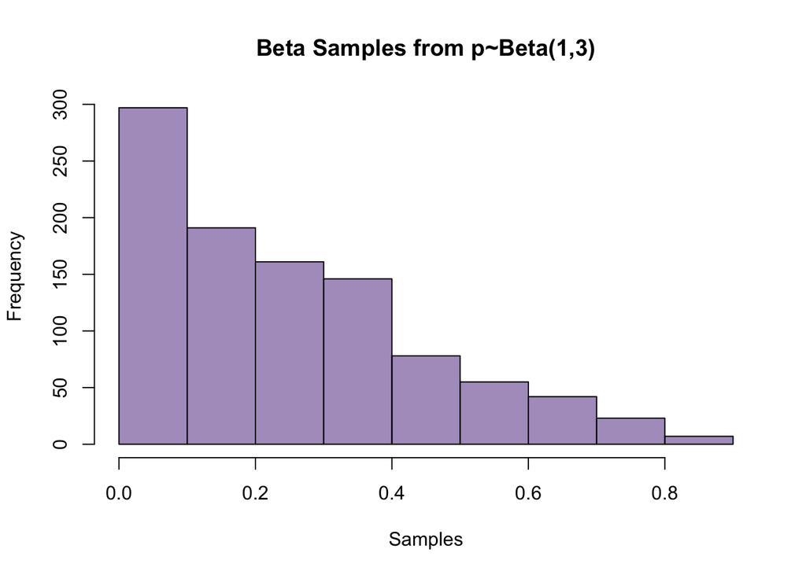

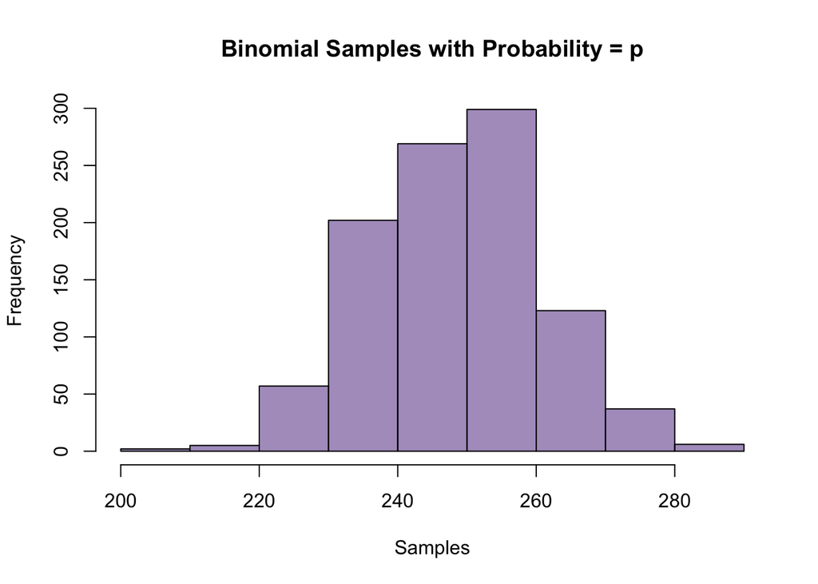

What if we have continuous data, that’s strictly positive, and bounded between $(0,\infty)$?

The normal distribution produces negative values, but that’s not too much of a problem if we set the mean high enough and the variance low enough:

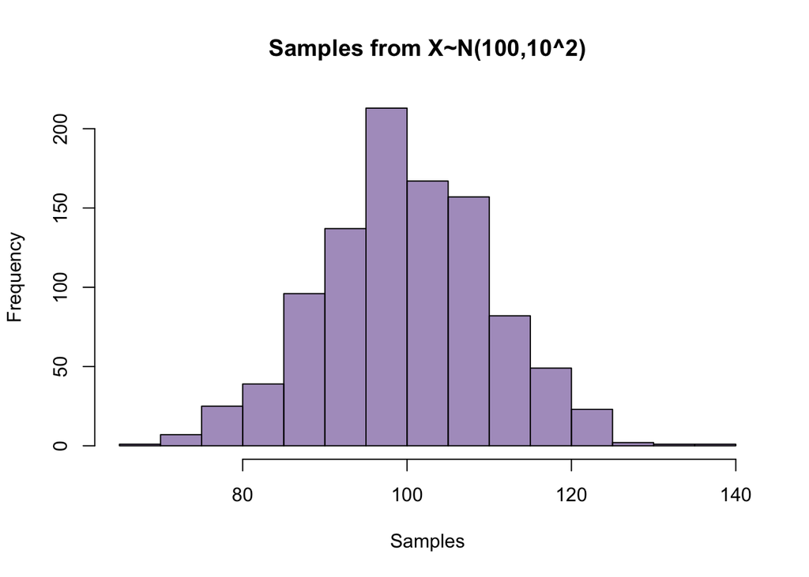

It doesn’t work as well if our variance gets high enough that negatives *are probable* (remember the idea of violating assumptions):

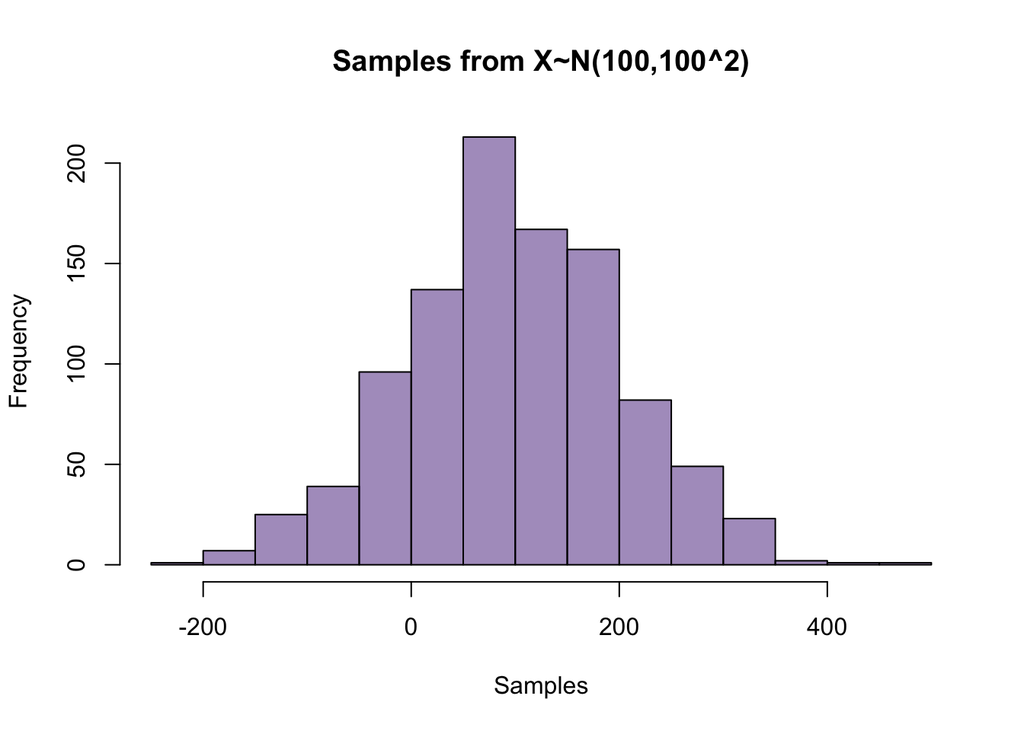

In this case we would use the **Gamma Distribution**:

$$X\sim \text{Gamma}(\alpha,\theta)$$

$\alpha$ controls the **shape** and $\theta$ controls the scale

Generally speaking, this distribution models the probability of certain continuous time steps:

- Waiting time at a bus stop
- Time for an insect population in a field to die out

$$\begin{array}{|c|c|}
\hline
\text{Distribution} & \text{Use-Case}\\
\hline
\text{Binomial} & \text{Binary (0,1) outcomes}\\
\hline
\text{Poisson} & \text{Positive, discrete counts}\\
\hline
\text{Beta} & \text{Proportions and probabilities}\\
\hline
\text{Gamma} & \text{Continuous, strictly positive data}\\
\hline
\end{array}$$

> Try for yourself. Assign distributions to each of the following data sources:
1. The presence/absence of a specific gene variant across 50 plant samples
2. The fraction of roots colonized by Mycorrhizal fungi
3. Milk production volumes across a herd of dairy cows
4. The success rate of different pollinator species visiting specific plant varieties
5. The amount of rainfall needed before a dormant seed will germinate
6. The number of new bacterial colonies appearing on a petri dish in a 24-hour period
7. Whether individual plants survive or die after exposure to a specific pathogen
8. The lifespan of insects in a laboratory colony